# Curso de Estatística Básica

19/10/2021

## Medidas-Resumo

- Medidas de Posição
- Medidas de Dispersão
- Quantis Empíricos

## Medidas de Posição

- Moda: Valor(es) mais frequente(s)
- Mediana: Medida central
- Média: Soma das observações dividida pelo número delas

## Moda

A moda é definida como a realização mais freqüente do conjunto de valores observados.

Vamos a um exemplo…

## Considerando a tabela da aula anterior

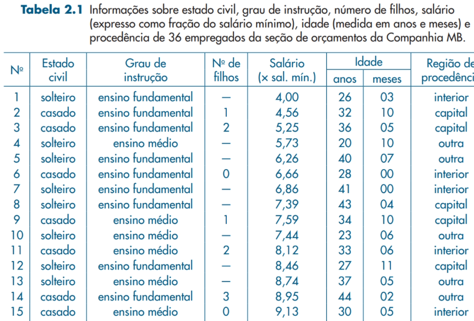

## Considerando a tabela da aula anterior

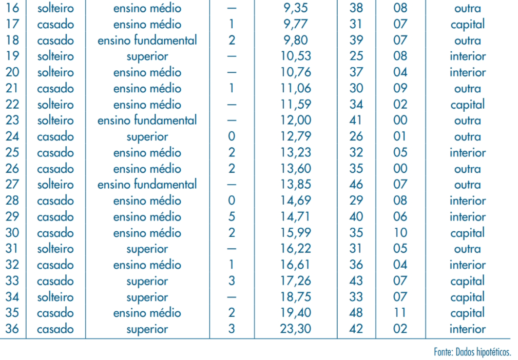

## Moda - Exemplo 1

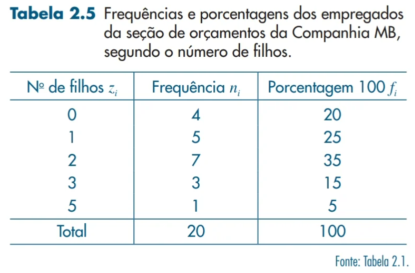

Qual é a moda?

## Moda - Exemplo 2

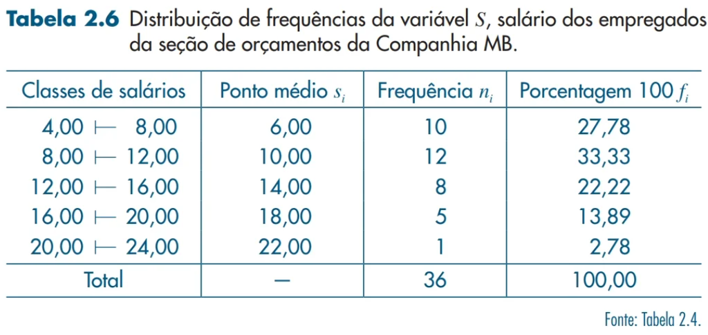

Qual é a moda?

## Mediana

A mediana é a realização que ocupa a **posição central** da série de observações, quando estão ordenadas em ordem crescente.

## Mediana - Exemplo 1

A mediana é a realização que ocupa a **posição central** da série de observações, quando estão ordenadas em ordem crescente.

Considere uma variável em que as **cinco** observações de uma variável são: 3, 4, 7, 8 e 8.

Qual é a mediana?

## Mediana - Exemplo 2

Quando o número de observações for par, usa-se como mediana a média aritmética das duas observações centrais.

Se acrescentarmos o valor 9 à série anterior, teremos **seis** observações: 3, 4, 7, 8, 8 e 9.

Neste caso, qual é a mediana?

## Média

É a soma das observações dividida pelo número delas.

\(\bar{x} = \frac{1}{n} \sum_{i=1}^{n}x_i\)

## Média - Exemplo 1

Considerando uma variável que tem cinco observações como no exemplo anterior: 3, 4, 7, 8 e 8

A média é calculada da seguinte forma:

\(\frac{(3+4+7+8+8)}{5} = 6\)

## Média - Exemplo 1

Observe que as cinco observações 3, 4, 7, 8 e 8 podem ser identificadas assim, \(x_1 = 3, x_2=4, x_3=7, x_4=8, x_5=8\).

Poderíamos então generalizar escrevendo: \(\frac{(x_1+x_2+x_3+x_4+x_5)}{5} = 6\)

Ou ainda: \(\frac{(x_1+...+x_5)}{5} = 6\)

Ou ainda: \(\frac{(x_1+...+x_n)}{n} = \bar{x}\)

Logo, podemos generalizar da seguinte forma: \(\bar{x} = \frac{1}{n} \sum_{i=1}^{n}x_i\)

## Média - Exemplo 2

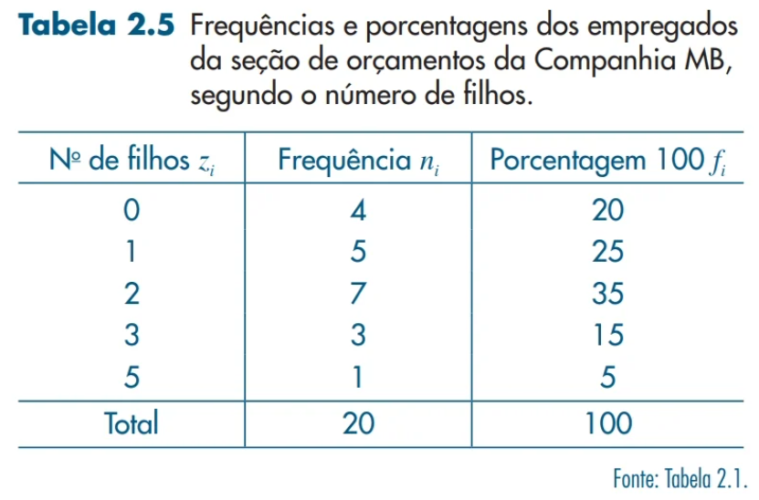

Qual é a média?